# Пример блокнота Rmarkdown

Заходякин Г.В., postlogist@gmail.com

05.09.2017

# Введение

В отличие от скрипта, документ Rmarkdown может содержать не только код, но и текстовые пояснения, графику, формулы и результаты расчетов. В RStudio документы Rmarkdown отображаются в виде блокнотов, которые включают текст и кодовые блоки, например:

```r
library(tidyverse)
```

Блоки кода можно выполнять пошагово (`Ctrl-Shift-Enter`), в нужном порядке, или все сразу (см. меню на кнопке `Run` в RStudio).

```r
data(mpg)
head(mpg)
```

```
## # A tibble: 6 x 11
##   manufacturer model displ  year   cyl      trans   drv   cty   hwy    fl
##          <chr> <chr> <dbl> <int> <int>      <chr> <chr> <int> <int> <chr>
## 1         audi    a4   1.8  1999     4   auto(l5)     f    18    29     p
## 2         audi    a4   1.8  1999     4 manual(m5)     f    21    29     p
## 3         audi    a4   2.0  2008     4 manual(m6)     f    20    31     p
## 4         audi    a4   2.0  2008     4   auto(av)     f    21    30     p
## 5         audi    a4   2.8  1999     6   auto(l5)     f    16    26     p
## 6         audi    a4   2.8  1999     6 manual(m5)     f    18    26     p
## # ... with 1 more variables: class <chr>
```

Результаты выводятся сразу после блока, что очень удобно.

Аналогичным образом выводятся графические и текстовые результаты.

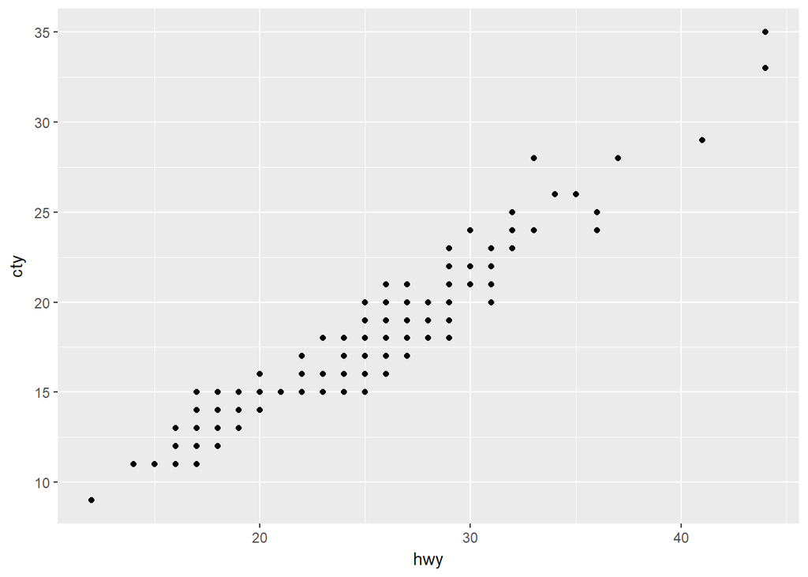

```r
# Визуализация данных
qplot(x = hwy, y = cty, data = mpg)
```

```r
# Расчет коэффициента корреляции
cor.test(~ cty + hwy, data = mpg)
```

```
##
##  Pearson's product-moment correlation
##
## data:  cty and hwy
## t = 49.585, df = 232, p-value < 2.2e-16
## alternative hypothesis: true correlation is not equal to 0
## 95 percent confidence interval:
##  0.9433129 0.9657663
## sample estimates:
##       cor
## 0.9559159
```

```r
# Построение модели
m_cty <- lm(cty ~ hwy, data = mpg)

# Сводка по подели
summary(m_cty)
```

```
##
## Call:
## lm(formula = cty ~ hwy, data = mpg)
##
## Residuals:
##     Min      1Q  Median      3Q     Max
## -2.9247 -0.7757 -0.0428  0.6965  4.6096
##
## Coefficients:
##             Estimate Std. Error t value Pr(>|t|)
## (Intercept)  0.84420    0.33319   2.534   0.0119 *
## hwy          0.68322    0.01378  49.585   <2e-16 ***
## ---
## Signif. codes:  0 '***' 0.001 '**' 0.01 '*' 0.05 '.' 0.1 ' ' 1
##
## Residual standard error: 1.252 on 232 degrees of freedom
## Multiple R-squared:  0.9138, Adjusted R-squared:  0.9134
## F-statistic:  2459 on 1 and 232 DF,  p-value: < 2.2e-16
```

Результаты расчетов можно встраивать в текст, например:

коэффициент детерминации модели равен 0.914.

Визуализируем полученную модель.

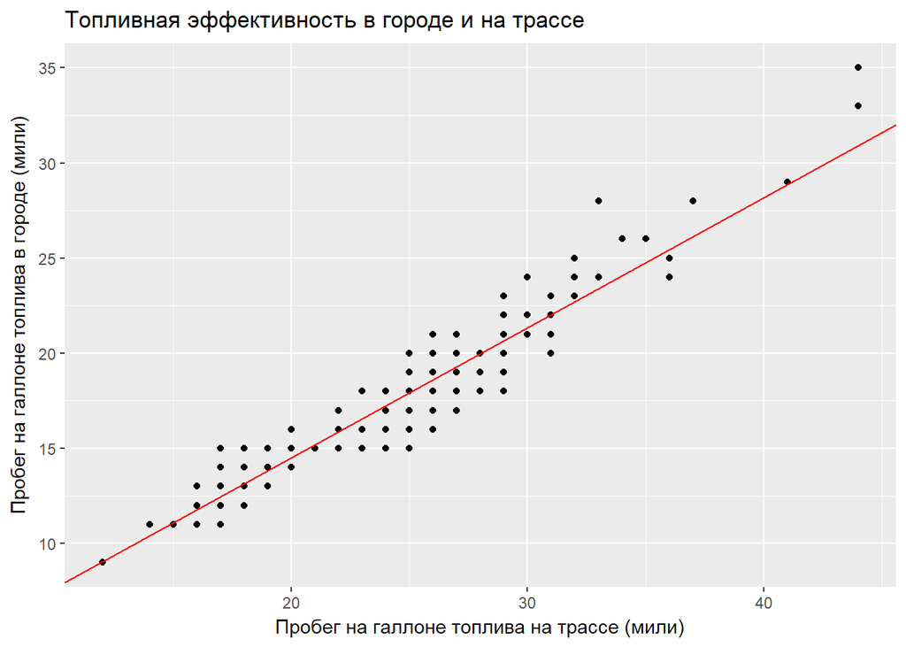

```r
# Получение коэффициентов модели
coef_m_cty <- coef(m_cty)

# Визуализация данных и тренда
qplot(x = hwy, y = cty, data = mpg) +
  geom_abline(intercept = coef_m_cty[1],
              slope = coef_m_cty[2],
              colour = "red") +
  labs(title = "Топливная эффективность в городе и на трассе",
       y = "Пробег на галлоне топлива в городе (мили)",
       x = "Пробег на галлоне топлива на трассе (мили)")
```

В отличие от скриптов, при обработке документов Rmarkdown предполагается, что рабочей директорией является та, в которой находится этот документ. Поэтому специально устанавливать рабочую директорию не требуется. Хранить исходные данные и результаты расчетов следует либо в одной папке с .Rmd документом, либо в ее подпапках.

```r
ggsave("example_plot_2.png")
```

Хотя мы видим в блокноте результаты расчетов, .Rmd - это простой текcтовый файл, в котором содержатся только текст пояснений и код. Результаты расчетов встраиваются только при отображении документа в RStudio. Это существенно облегчает использование блокнотов с системами контроля версий, например git/Github, поскольку они предназначены для отслеживания изменений в текстовых файлах.

Если необходимо отправить результаты анализа другому человеку, то можно преобразовать документ Rmarkdown в HTML. В полученном файле будет содержаться отформатированный отчет по ходу анализа, код и результаты его выполнения. Всё необходимое будет встроено в один HTML-файл, который можно просмотреть в браузере на любом устройстве, даже если там нет R. Помимо HTML доступны и другие форматы, например Word.

Для получения HTML из документа Rmarkdown необходимо нажать кнопку `Knit` в окне RStudio.

# Пример анализа данных из Интернет

R может загружать данные не только из файлов, но и из Интернет. В качестве примера, загрузим и исследуем временной ряд из [Единого архива экономических и социально-демографических данных НИУ ВШЭ](http://sophist.hse.ru).

Для работу потребуются пакеты `forecast` и `sophisthse`, которые входят в подготовленный для курса дистрибутив. Если вы устанавливали R сами и не добавляли эти пакеты, то раскомментируйте код в следующем блоке и выполните его:

```r
#install.packages("forecast")
#install.packages("sophisthse")
```

Загрузим пакеты (обычно это делается в самом начале блокнота)

```r
library(forecast)
library(sophisthse)
```

Загрузим данные об обороте розничной торговли в России.

```r
retail <- sophisthse('RTRD_M')
head(retail)
```

```
##          RTRD_M_DIRI RTRD_M_DIRI_SA RTRD_M
## Jan 1994       100.0          107.1     NA
## Feb 1994       100.0          108.2     NA
## Mar 1994       117.7          109.0     NA
## Apr 1994       107.6          109.4     NA
## May 1994       102.0          109.8     NA
## Jun 1994       106.6          110.7     NA
```

```r
sophisthse_metadata(retail)
```

```
## # A tibble: 3 x 7
##           tsname             unit
##            <chr>            <chr>
## 1    RTRD_M_DIRI       1994.1=100
## 2 RTRD_M_DIRI_SA 1994.1(факт)=100
## 3         RTRD_M        млрд.руб.
## # ... with 5 more variables: fullname <chr>, methodology <chr>,
## #   source <chr>, comment <chr>, freq <dbl>
```

Отберем данные только по ряду: `Оборот розничной торговли в текущих ценах (RTRD_M)` и посмотрим, как выглядит ряд на графике.

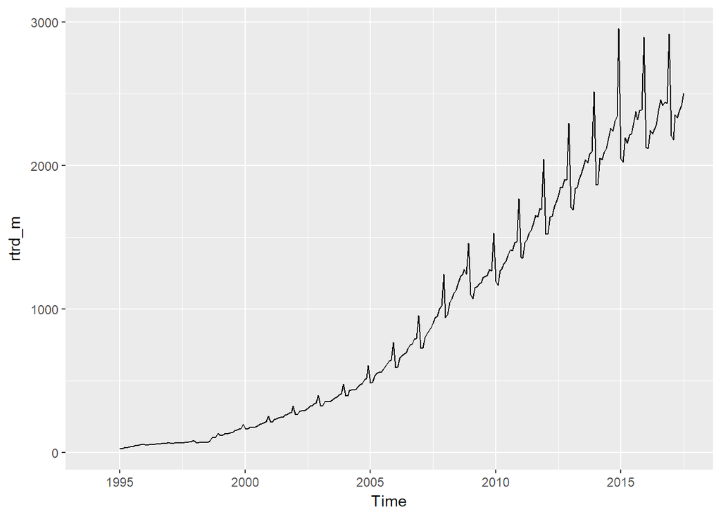

```r
rtrd_m <- retail[, 'RTRD_M']
autoplot(rtrd_m)
```

Исторических данных очень много, оставим данные только с 2010 года.

```r
rtrd_subset <- window(rtrd_m, start = c(2010, 1)) #год и месяц начала
```

Изучим структуру временного ряда с помощью декомпозиции.

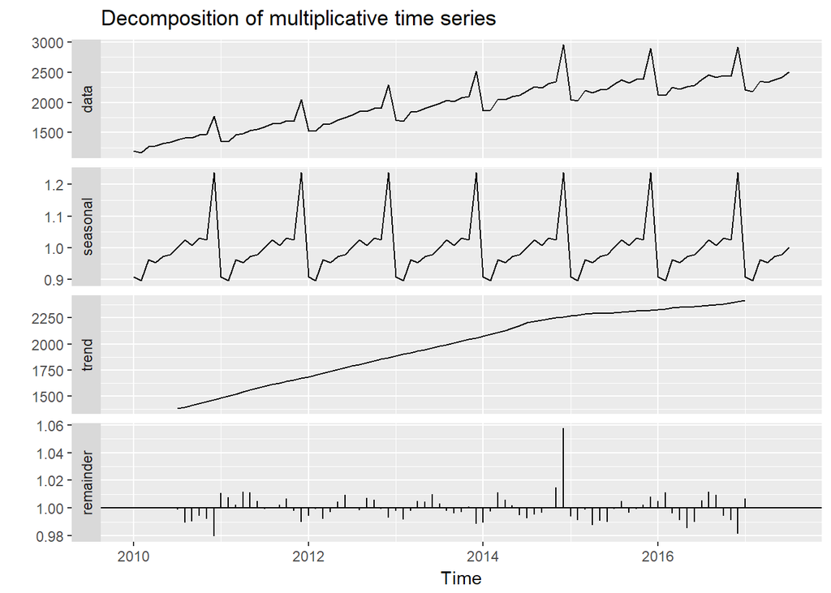

```r
autoplot(decompose(rtrd_subset, type = 'multiplicative'))
```

Видим, что после кризиса 2014 года рост отрасли замедлился.

Построим прогноз временного ряда. Вначале необходимо построить модель на основе исторических данных.Модель будет подобрана автоматически из семейства моделей экспоненциального сглаживания.

```r
m_rtrd_subset <- ets(rtrd_subset)
summary(m_rtrd_subset)
```

```
## ETS(M,Ad,M)
##
## Call:
##  ets(y = rtrd_subset)
##
##   Smoothing parameters:
##     alpha = 0.6158
##     beta  = 0.0305
##     gamma = 1e-04
##     phi   = 0.98
##
##   Initial states:
##     l = 1264.8962
##     b = 22.3047
##     s=1.2369 1.026 1.0304 1.0074 1.0251 1.0023
##            0.9772 0.9716 0.9539 0.9614 0.896 0.912
##
##   sigma:  0.0114
##
##      AIC     AICc      BIC
## 1008.813 1018.313 1054.009
##
## Training set error measures:
##                    ME     RMSE      MAE       MPE      MAPE      MASE
## Training set 2.560809 24.66578 16.11283 0.1125638 0.8013259 0.1002168
##                   ACF1
## Training set 0.0303739
```

Получив модель, можно построить по ней прогноз. Выберем в качестве горизонта прогнозирования 24 месяца.

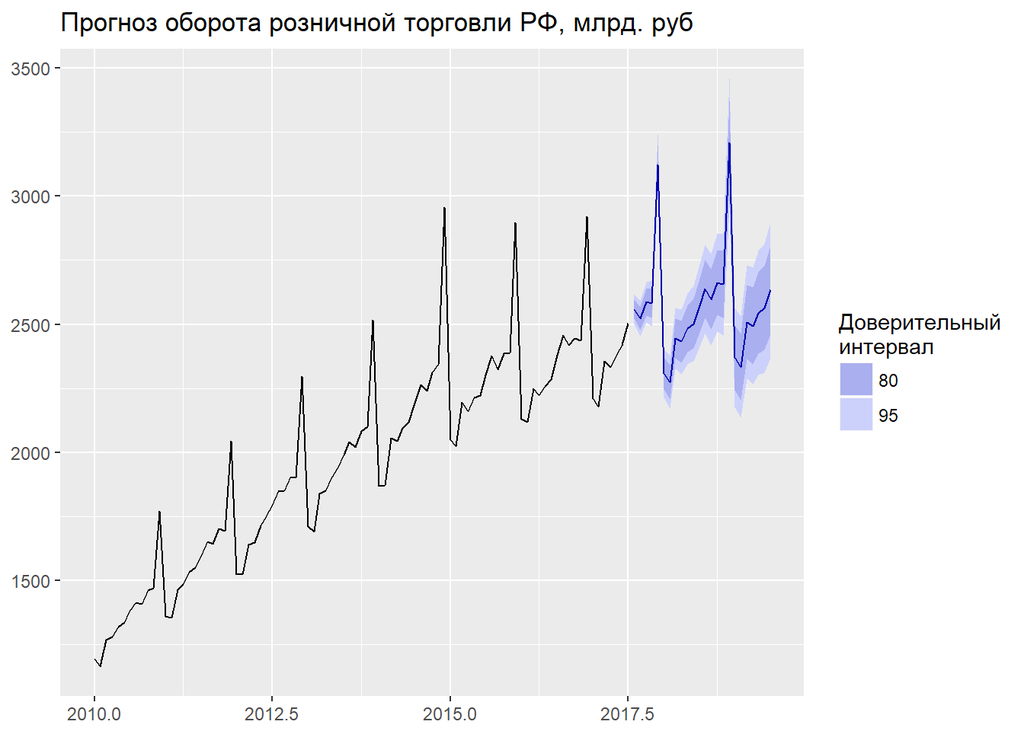

```r
f_rtrd_subset <- forecast(m_rtrd_subset, h = 24)
autoplot(f_rtrd_subset) +
  labs(title = "Прогноз оборота розничной торговли РФ, млрд. руб",
       x = NULL,
       y = NULL,
       fill = "Доверительный\nинтервал")
```